# Chapter 07: Analysis of Function: Sentence Modes and Nuclear Contours - No register

## **Raw Data**

### Nuclear Contour by speaker

| speaker | L*H % | L*H L% | >H* L% | H* L% |
| --- | --- | --- | --- | --- |
| F5 | 43 | 16 | 0 | 0 |
| F6 | 56 | 4 | 0 | 0 |
| F12 | 22 | 38 | 0 | 0 |
| F15 | 57 | 3 | 0 | 0 |
| F16 | 60 | 0 | 0 | 0 |
| F17 | 53 | 2 | 0 | 0 |
| M4 | 57 | 0 | 0 | 0 |
| M5 | 60 | 0 | 0 | 0 |
| M8 | 37 | 17 | 5 | 2 |
| M9 | 33 | 14 | 0 | 0 |
| M10 | 44 | 16 | 0 | 0 |

### Nuclear Contour by Sentence Mode

[output not shown]

#### Chi Squared test of association using raw data

```
##
##  Pearson's Chi-squared test
##
## data:  .
## X-squared = NaN, df = 33, p-value = NA
```

## **Adjusted Data**

The raw data is unbalanced since there number of utterances per target speaker varies slightly. For some speakers, there are no repetitions of some target utterances. Therefore, the data has been adjusted to project an estimated balanced number of tokens per speaker per target utterance.

This is done in three stages, using the local function `balancedData()`: 1. The function calculates the ratio of each token per target per speaker. This is multiplies by a constant reflecting the target number of token for that utterance. 2. It then calculates the total number of tokens per target as a proportion of the actual number of speakers for each target. Again, this is multiplied by a constant to reflect the ideal target number of speakers per target. 3. The resulting values are rounded to an integer to approximate the projected ideal number of total tokens per speaker per utterance.

### Nuclear Contour by Speaker

| speaker | L*H % | L*H L% | >H* L% | H* L% |
| --- | --- | --- | --- | --- |
| F5 | 44 | 16 | 0 | 0 |
| F6 | 56 | 4 | 0 | 0 |
| F12 | 22 | 38 | 0 | 0 |
| F15 | 57 | 3 | 0 | 0 |
| F16 | 60 | 0 | 0 | 0 |
| F17 | 58 | 2 | 0 | 0 |
| M4 | 60 | 0 | 0 | 0 |
| M5 | 60 | 0 | 0 | 0 |
| M8 | 36 | 17 | 5 | 2 |
| M9 | 42 | 18 | 0 | 0 |
| M10 | 44 | 16 | 0 | 0 |

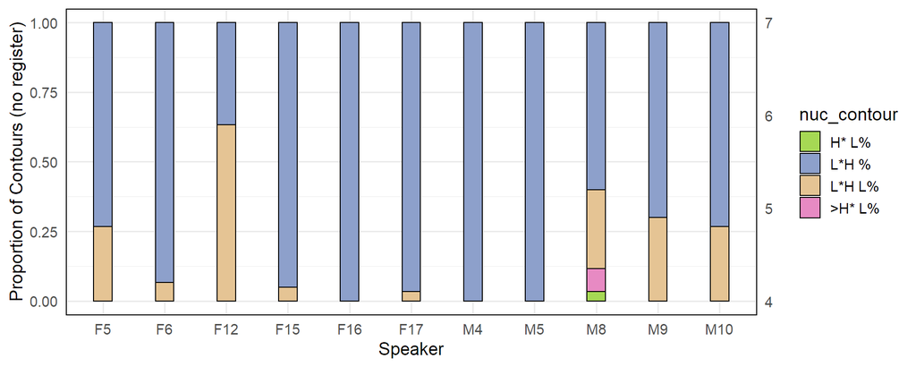

### Nuclear Contour by Sentence Mode

| mode | >H* L% | H* L% | L*H % | L*H L% |
| --- | --- | --- | --- | --- |
| MDC | 2 | 2 | 144 | 18 |
| MWH | 0 | 0 | 148 | 17 |
| MYN | 2 | 0 | 132 | 30 |
| MDQ | 1 | 0 | 112 | 52 |

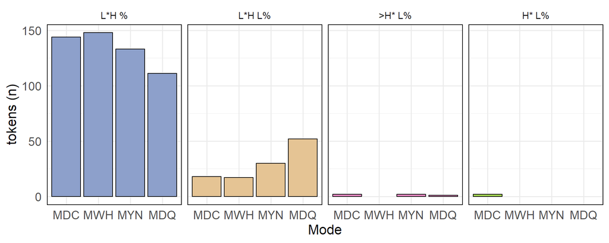

#### Chi Squared test of association using adjusted data

```
##
##  Pearson's Chi-squared test
##
## data:  .
## X-squared = 41.598, df = 9, p-value = 3.892e-06
```

Overall, mode appears to be somewhat related to theuse of L%.